# Rapport dynamique HTML sur la Regression logistique

Abraham_KINNIN

2024-09-01

# Regression logistique

La régression logistique est fréquemment utilisée en sciences sociales car elle permet d’effectuer un raisonnement dit *toutes choses étant égales par ailleurs*. Plus précisément, la régression logistique a pour but d’isoler les effets de chaque variable, c’est-à-dire d’identifier les effets résiduels d’une variable explicative sur une variable d’intérêt, une fois pris en compte les autres variables explicatives introduites dans le modèle. La régression logistique est ainsi prisée en épidémiologie pour identifier les facteurs associés à telle ou telle pathologie.

La régression logistique ordinaire ou régression logistique binaire vise à expliquer une variable d’intérêt binaire (c’est-à-dire de type « oui / non » ou « vrai / faux »). Les variables explicatives qui seront introduites dans le modèle peuvent être quantitatives ou qualitatives.

La régression logistique multinomiale est une extension de la régression logistique aux variables qualitatives à trois modalités ou plus, la régression logistique ordinale aux variables qualitatives à trois modalités ou plus qui sont ordonnées hiérarchiquement.

## Préparation des données

Dans ce chapite, nous allons encore une fois utiliser les données de l’enquête *Histoire de vie*, fournies avec l’extension `questionr`.

```r
library(questionr)
data(hdv2003)
d <- hdv2003
```

À titre d’exemple, nous allons étudier l’effet de l’âge, du sexe, du niveau d’étude, de la pratique religieuse et du nombre moyen d’heures passées à regarder la télévision par jour sur le fait de pratiquer un sport.

En premier lieu, il importe de vérifier que notre variable d’intérêt (ici *sport*) est correctement codée. Une possibilité consiste à créer une variable booléenne , variable (vrai / faux) selon que l’individu a pratiqué du sport ou non :

```r
d$sport2 <- FALSE
d$sport2[d$sport == "Oui"] <- TRUE
```

Dans le cas présent, cette variable n’a pas de valeur manquante. Mais, le cas échéant, il importe de bien coder les valeurs manquantes en `NA`, les individus en question étant alors exclu de l’analyse.

Il n’est pas forcément nécessaire de transformer notre variable d’intérêt en variable booléenne. En effet, **R** accepte sans problème une variable de type facteur. Cependant, l’ordre des valeurs d’un facteur a de l’importance. En effet, **R** considère toujours la première modalité comme étant la modalité de référence. Dans le cas de la variable d’intérêt, la modalité de référence correspond au fait de ne pas remplir le critère étudié, dans notre exemple au fait de ne pas avoir eu d’activité sportive au cours des douze derniers mois.

Pour connaître l’ordre des modalités d’une variable de type facteur, on peut utiliser la fonction `levels` ou bien encore tout simplement la fonction `freq` de l’extension `questionr` :

```r
levels(d$sport)
```

```
## [1] "Non" "Oui"
```

```r
freq(d$sport)
```

```
##        n    % val%
## Non 1277 63.8 63.8
## Oui  723 36.1 36.1
```

Dans notre exemple, la modalité « Non » est déjà la première modalité. Il n’y a donc pas besoin de modifier notre variable. Si ce n’est pas le cas, il faudra modifier la modalité de référence avec la fonction `relevel` comme nous allons le voir un peu plus loin.

Il est possible d’indiquer un facteur à plus de deux modalités. Dans une telle situation, **R** considérera que tous les modalités, sauf la modalité de référence, est une réalisation de la variable d’intérêt. Cela serait correct, par exemple, si notre variable *sport* était codée ainsi : « Non », « Oui, toutes les semaines », « Oui, au moins une fois par mois », « Oui, moins d’une fois par mois ». Cependant, afin d’éviter tout risque d’erreur ou de mauvaise interprétation, il est vivement conseillé de recoder au préalable sa variable d’intérêt en un facteur à deux modalités.

La notion de modalité de référence s’applique également aux variables explicatives qualitatives. En effet, dans un modèle, tous les coefficients sont calculés par rapport à la modalité de référence. Il importe de choisir une modalité de référence qui fasse sens afin de faciliter l’interprétation. Par ailleurs, ce choix peut également dépendre de la manière dont on souhaite présenter les résultats. De manière générale on évitera de choisir comme référence une modalité peu représentée dans l’échantillon ou bien une modalité correspondant à une situation atypique.

Prenons l’exemple de la variable *sexe*. Souhaite-t-on connaitre l’effet d’être une femme par rapport au fait d’être un homme ou bien l’effet d’être un homme par rapport au fait d’être une femme ? Si l’on opte pour le second, alors notre modalité de référence sera le sexe féminin. Comme est codée cette variable ?

```r
freq(d$sexe)
```

```
##          n  % val%
## Homme  899 45   45
## Femme 1101 55   55
```

La modalité « Femme » s’avère ne pas être la première modalité. Nous devons appliquer la fonction `relevel` :

```r
d$sexe <- relevel(d$sexe, "Femme")
freq(d$sexe)
```

```
##          n  % val%
## Femme 1101 55   55
## Homme  899 45   45
```

**Données labellisées**

Si l’on utilise des données labellisées (voir le chapitre dédié), nos variables catégorielles seront stockées sous la forme d’un vecteur numérique avec des étiquettes. Il sera donc nécessaire de convertir ces variables en facteurs, tout simplement avec la fonction `to_factor` de l’extension `labelled` qui pourra utiliser les étiquettes de valeurs comme modalités du facteur.

Les variables *age* et *heures.tv* sont des variables quantitatives. Il importe de vérifier qu’elles sont bien enregistrées en tant que variables numériques. En effet, il arrive parfois que dans le fichier source les variables quantitatives soient renseignées sous forme de valeur textuelle et non sous forme numérique.

```r
str(d$age)
```

```
##  int [1:2000] 28 23 59 34 71 35 60 47 20 28 ...
```

```r
str(d$heures.tv)
```

```
##  num [1:2000] 0 1 0 2 3 2 2.9 1 2 2 ...
```

Nos deux variables sont bien renseignées sous forme numérique.

Cependant, l’effet de l’âge est rarement linéaire. Un exemple trivial est par exemple le fait d’occuper un emploi qui sera moins fréquent aux jeunes âges et aux âges élevés. Dès lors, on pourra transformer la variable *age* en groupe d’âges avec la fonction `cut` (voir le chapitre Manipulation de données) :

```r
d$grpage <- cut(d$age, c(16, 25, 45, 65, 99), right = FALSE, include.lowest = TRUE)
freq(d$grpage)
```

```
##           n    % val%
## [16,25) 169  8.5  8.5
## [25,45) 706 35.3 35.3
## [45,65) 745 37.2 37.2
## [65,99] 380 19.0 19.0
```

Jetons maintenant un oeil à la variable *nivetud* :

```r
freq(d$nivetud)
```

```
##                                                                   n    % val%
## N'a jamais fait d'etudes                                         39  2.0  2.1
## A arrete ses etudes, avant la derniere annee d'etudes primaires  86  4.3  4.6
## Derniere annee d'etudes primaires                               341 17.0 18.1
## 1er cycle                                                       204 10.2 10.8
## 2eme cycle                                                      183  9.2  9.7
## Enseignement technique ou professionnel court                   463 23.2 24.5
## Enseignement technique ou professionnel long                    131  6.6  6.9
## Enseignement superieur y compris technique superieur            441 22.0 23.4
## NA                                                              112  5.6   NA
```

En premier lieu, cette variable est détaillée en pas moins de huit modalités dont certaines sont peu représentées (seulement 39 individus soit 2 % n’ont jamais fait d’études par exemple). Afin d’améliorier notre modèle logistique, il peut être pertinent de regrouper certaines modalités (voir le chapitre Manipulation de données) :

```r
d$etud <- d$nivetud
levels(d$etud) <- c(
  "Primaire", "Primaire", "Primaire",
  "Secondaire", "Secondaire", "Technique/Professionnel",
  "Technique/Professionnel", "Supérieur"
  )
freq(d$etud)
```

```
##                           n    % val%
## Primaire                466 23.3 24.7
## Secondaire              387 19.4 20.5
## Technique/Professionnel 594 29.7 31.5
## Supérieur               441 22.0 23.4
## NA                      112  5.6   NA
```

Notre variable comporte également 112 individus avec une valeur manquante. Si nous conservons cette valeur manquante, ces 112 individus seront, par défaut, exclus de l’analyse. Ces valeurs manquantes n’étant pas négligeable (5,6 %), nous pouvons également faire le choix de considérer ces valeurs manquantes comme une modalité supplémentaire. Auquel cas, nous utiliserons la fonction `addNAstr` fournie par `questionr`[^1] :

```r
levels(d$etud)
```

```
## [1] "Primaire"                "Secondaire"
## [3] "Technique/Professionnel" "Supérieur"
```

```r
d$etud <- addNAstr(d$etud, "manquant")
levels(d$etud)
```

```
## [1] "Primaire"                "Secondaire"
## [3] "Technique/Professionnel" "Supérieur"
## [5] "manquant"
```

## Régression logistique binaire

La fonction `glm` (pour generalized linear models soit modèle linéaire généralisé en français) permet de calculer une grande variété de modèles statistiques. La régression logistique ordinaire correspond au modèle *logit* de la famille des modèles binomiaux, ce que l’on indique à `glm` avec l’argument `family=binomial(logit)`.

Le modèle proprement dit sera renseigné sous la forme d’une formule (que nous avons déjà rencontrée dans le chapitre sur la statistique bivariée et présentée plus en détails dans un chapitre dédié). On indiquera d’abord la variable d’intérêt, suivie du signe `~` (que l’on obtient en appuyant sur les touches

```
Alt
Gr
```

et `3` sur un clavier de type PC) puis de la liste des variables explicatives séparées par un signe `+`. Enfin, l’argument `data` permettra d’indiquer notre tableau de données.

```r
reg <- glm(sport ~ sexe + grpage + etud + relig + heures.tv, data = d, family = binomial(logit))
reg
```

```
##
## Call:  glm(formula = sport ~ sexe + grpage + etud + relig + heures.tv,
##     family = binomial(logit), data = d)
##
## Coefficients:
##                      (Intercept)                         sexeHomme
##                        -0.798368                          0.439694
##                    grpage[25,45)                     grpage[45,65)
##                        -0.420448                         -1.085434
##                    grpage[65,99]                    etudSecondaire
##                        -1.381353                          0.950571
##      etudTechnique/Professionnel                     etudSupérieur
##                         1.049253                          1.891667
##                     etudmanquant       religPratiquant occasionnel
##                         2.150428                         -0.021904
##  religAppartenance sans pratique  religNi croyance ni appartenance
##                        -0.006696                         -0.215389
##                       religRejet                  religNSP ou NVPR
##                        -0.383543                         -0.083789
##                        heures.tv
##                        -0.120911
##
## Degrees of Freedom: 1994 Total (i.e. Null);  1980 Residual
##   (5 observations deleted due to missingness)
## Null Deviance:       2609
## Residual Deviance: 2206  AIC: 2236
```

Il est possible de spécifier des modèles plus complexes. Par exemple, `x:y` permet d’indiquer l’interaction entre les variables *x* et *y*. `x * y` sera équivalent à `x + y + x:y`. Pour aller plus loin, voir http://ww2.coastal.edu/kingw/statistics/R-tutorials/formulae.html.

Une présentation plus complète des résultats est obtenue avec la méthode `summary` :

```r
summary(reg)
```

```
##
## Call:
## glm(formula = sport ~ sexe + grpage + etud + relig + heures.tv,
##     family = binomial(logit), data = d)
##
## Coefficients:
##                                   Estimate Std. Error z value Pr(>|z|)
## (Intercept)                      -0.798368   0.323903  -2.465 0.013708 *
## sexeHomme                         0.439694   0.106062   4.146 3.39e-05 ***
## grpage[25,45)                    -0.420448   0.228053  -1.844 0.065236 .
## grpage[45,65)                    -1.085434   0.237716  -4.566 4.97e-06 ***
## grpage[65,99]                    -1.381353   0.273796  -5.045 4.53e-07 ***
## etudSecondaire                    0.950571   0.197442   4.814 1.48e-06 ***
## etudTechnique/Professionnel       1.049253   0.189804   5.528 3.24e-08 ***
## etudSupérieur                     1.891667   0.195218   9.690  < 2e-16 ***
## etudmanquant                      2.150428   0.330229   6.512 7.42e-11 ***
## religPratiquant occasionnel      -0.021904   0.189199  -0.116 0.907833
## religAppartenance sans pratique  -0.006696   0.174737  -0.038 0.969434
## religNi croyance ni appartenance -0.215389   0.193080  -1.116 0.264617
## religRejet                       -0.383543   0.285905  -1.342 0.179756
## religNSP ou NVPR                 -0.083789   0.411028  -0.204 0.838470
## heures.tv                        -0.120911   0.033591  -3.599 0.000319 ***
## ---
## Signif. codes:  0 '***' 0.001 '**' 0.01 '*' 0.05 '.' 0.1 ' ' 1
##
## (Dispersion parameter for binomial family taken to be 1)
##
##     Null deviance: 2609.2  on 1994  degrees of freedom
## Residual deviance: 2206.2  on 1980  degrees of freedom
##   (5 observations deleted due to missingness)
## AIC: 2236.2
##
## Number of Fisher Scoring iterations: 4
```

Dans le cadre d’un modèle logistique, généralement on ne présente pas les coefficients du modèle mais leur valeur exponentielle, cette dernière correspondant en effet à des odds ratio, également appelés rapports des cotes. L’odds ratio diffère du risque relatif. Cependent son interprétation est similaire. Un *odds ratio* de 1 signifie l’absence d’effet. Un *odds ratio* largement supérieur à 1 correspond à une augmentation du phénomène étudié et un *odds ratio* largement inféieur à 1 correspond à une diminution du phénomène étudié[^2].

La fonction `coef` permet d’obtenir les coefficients d’un modèle, `confint` leurs intervalles de confiance et `exp` de calculer l’exponentiel. Les *odds ratio* et leurs intervalles de confiance s’obtiennent ainsi :

```r
exp(coef(reg))
```

```
##                      (Intercept)                        sexeHomme
##                        0.4500628                        1.5522329
##                    grpage[25,45)                    grpage[45,65)
##                        0.6567525                        0.3377552
##                    grpage[65,99]                   etudSecondaire
##                        0.2512383                        2.5871865
##      etudTechnique/Professionnel                    etudSupérieur
##                        2.8555168                        6.6304155
##                     etudmanquant      religPratiquant occasionnel
##                        8.5885303                        0.9783342
##  religAppartenance sans pratique religNi croyance ni appartenance
##                        0.9933267                        0.8062276
##                       religRejet                 religNSP ou NVPR
##                        0.6814428                        0.9196256
##                        heures.tv
##                        0.8861129
```

```r
exp(confint(reg))
```

```
##                                      2.5 %     97.5 %
## (Intercept)                      0.2377004  0.8473181
## sexeHomme                        1.2614265  1.9120047
## grpage[25,45)                    0.4194391  1.0274553
## grpage[45,65)                    0.2115307  0.5380894
## grpage[65,99]                    0.1463860  0.4288023
## etudSecondaire                   1.7652682  3.8327896
## etudTechnique/Professionnel      1.9804881  4.1729378
## etudSupérieur                    4.5517938  9.7950691
## etudmanquant                     4.5347799 16.5885323
## religPratiquant occasionnel      0.6758807  1.4198530
## religAppartenance sans pratique  0.7063000  1.4020242
## religNi croyance ni appartenance 0.5524228  1.1782475
## religRejet                       0.3868800  1.1889781
## religNSP ou NVPR                 0.3996746  2.0215562
## heures.tv                        0.8290223  0.9457756
```

On pourra faciliter la lecture en combinant les deux :

```r
exp(cbind(coef(reg), confint(reg)))
```

```
##                                                2.5 %     97.5 %
## (Intercept)                      0.4500628 0.2377004  0.8473181
## sexeHomme                        1.5522329 1.2614265  1.9120047
## grpage[25,45)                    0.6567525 0.4194391  1.0274553
## grpage[45,65)                    0.3377552 0.2115307  0.5380894
## grpage[65,99]                    0.2512383 0.1463860  0.4288023
## etudSecondaire                   2.5871865 1.7652682  3.8327896
## etudTechnique/Professionnel      2.8555168 1.9804881  4.1729378
## etudSupérieur                    6.6304155 4.5517938  9.7950691
## etudmanquant                     8.5885303 4.5347799 16.5885323
## religPratiquant occasionnel      0.9783342 0.6758807  1.4198530
## religAppartenance sans pratique  0.9933267 0.7063000  1.4020242
## religNi croyance ni appartenance 0.8062276 0.5524228  1.1782475
## religRejet                       0.6814428 0.3868800  1.1889781
## religNSP ou NVPR                 0.9196256 0.3996746  2.0215562
## heures.tv                        0.8861129 0.8290223  0.9457756
```

Pour savoir si un *odds ratio* diffère significativement de 1 (ce qui est identique au fait que le coefficient soit différent de 0), on pourra se référer à la colonne *Pr(>|z|)* obtenue avec `summary`.

Si vous disposez de l’extension `questionr`, la fonction `odds.ratio` permet de calculer directement les *odds ratio*, leur intervalles de confiance et les *p-value* :

```r
library(questionr)
odds.ratio(reg)
```

```
##                                       OR   2.5 %  97.5 %         p
## (Intercept)                      0.45006 0.23770  0.8473 0.0137076 *
## sexeHomme                        1.55223 1.26143  1.9120 3.389e-05 ***
## grpage[25,45)                    0.65675 0.41944  1.0275 0.0652358 .
## grpage[45,65)                    0.33776 0.21153  0.5381 4.969e-06 ***
## grpage[65,99]                    0.25124 0.14639  0.4288 4.531e-07 ***
## etudSecondaire                   2.58719 1.76527  3.8328 1.476e-06 ***
## etudTechnique/Professionnel      2.85552 1.98049  4.1729 3.237e-08 ***
## etudSupérieur                    6.63042 4.55179  9.7951 < 2.2e-16 ***
## etudmanquant                     8.58853 4.53478 16.5885 7.419e-11 ***
## religPratiquant occasionnel      0.97833 0.67588  1.4199 0.9078331
## religAppartenance sans pratique  0.99333 0.70630  1.4020 0.9694337
## religNi croyance ni appartenance 0.80623 0.55242  1.1782 0.2646171
## religRejet                       0.68144 0.38688  1.1890 0.1797562
## religNSP ou NVPR                 0.91963 0.39967  2.0216 0.8384696
## heures.tv                        0.88611 0.82902  0.9458 0.0003188 ***
## ---
## Signif. codes:  0 '***' 0.001 '**' 0.01 '*' 0.05 '.' 0.1 ' ' 1
```

### Représentation graphique du modèle

Il est possible de représenter graphiquement les différents odds ratios. Pour cela, on va utiliser la fonction `tidy` de l’extension `broom` pour récupérer les coefficients du modèle sous la forme d’un tableau de données exploitable avec `ggplot2`. On précisera `conf.int = TRUE` pour obtenir les intervalles de confiance et `exponentiate = TRUE` pour avoir les odds ratio plutôt que les coefficients bruts. `geom_errorbarh` permets de représenter les intervalles de confiance sous forme de barres d’erreurs, `geom_vline` une ligne verticale au niveau `x = 1`, `scale_x_log10` pour afficher l’axe des `x` de manière logarithmique, les odds ratios étant de nature multiplicative et non additive.

```r
library(broom)
tmp <- tidy(reg, conf.int = TRUE, exponentiate = TRUE)
str(tmp)
```

```
## tibble [15 × 7] (S3: tbl_df/tbl/data.frame)
##  $ term     : chr [1:15] "(Intercept)" "sexeHomme" "grpage[25,45)" "grpage[45,65)" ...
##  $ estimate : num [1:15] 0.45 1.552 0.657 0.338 0.251 ...
##  $ std.error: num [1:15] 0.324 0.106 0.228 0.238 0.274 ...
##  $ statistic: num [1:15] -2.46 4.15 -1.84 -4.57 -5.05 ...
##  $ p.value  : num [1:15] 1.37e-02 3.39e-05 6.52e-02 4.97e-06 4.53e-07 ...
##  $ conf.low : num [1:15] 0.238 1.261 0.419 0.212 0.146 ...
##  $ conf.high: num [1:15] 0.847 1.912 1.027 0.538 0.429 ...
```

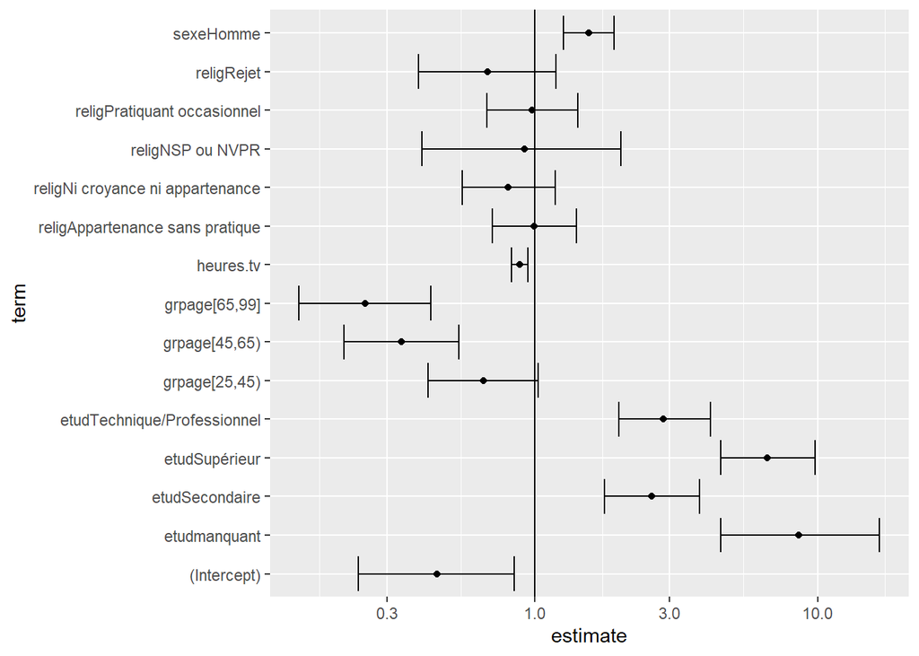

Représentation graphique des odds ratios

```r
library(ggplot2)
ggplot(tmp) +
  aes(x = estimate, y = term, xmin = conf.low, xmax = conf.high) +
  geom_vline(xintercept = 1) +
  geom_errorbarh() +
  geom_point() +
  scale_x_log10()
```

La fonction `ggcoef` de l’extension `GGally` permet d’effectuer le graphique précédent directement à partir de notre modèle. Voir l’aide de cette fonction pour la liste complète des paramètres personnalisables.

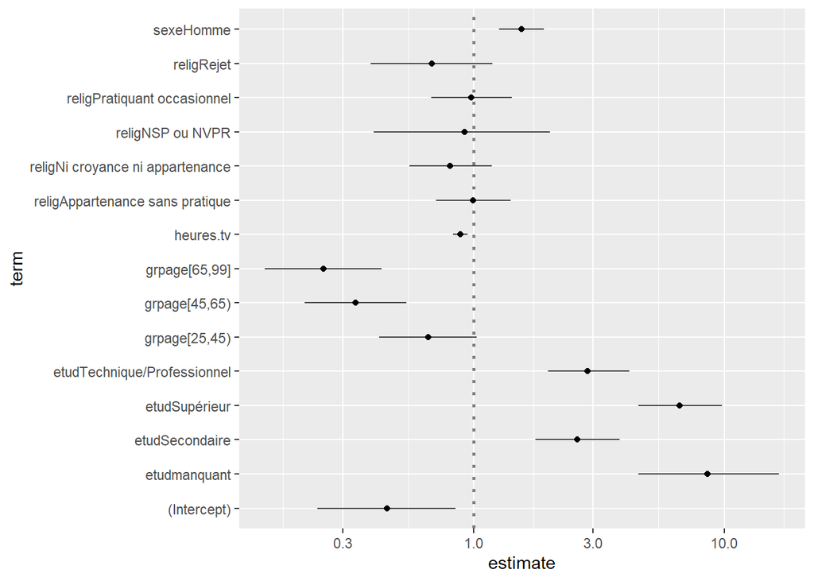

La fonction ggcoef

```r
library(GGally)
ggcoef(reg, exponentiate = TRUE)
```

### Représentation graphique des effets

L’extension `effects` propose une représentation graphique résumant les effets de chaque variable du modèle. Pour cela, il suffit d’appliquer la méthode `plot` au résultat de la fonction `allEffects`. Nous obtenons alors la figure ci-dessous.

```r
library(effects)
```

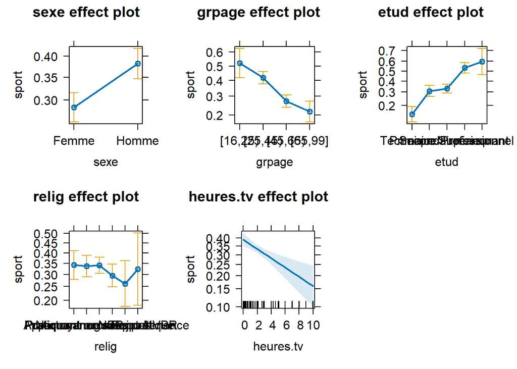

Représentation graphique de l’effet de chaque variable du modèle logistique

```r
plot(allEffects(reg))
```

Une manière de tester la qualité d’un modèle est le calcul d’une matrice de confusion, c’est-à-dire le tableau croisé des valeurs observées et celles des valeurs prédites en appliquant le modèle aux données d’origine.

La méthode `predict` avec l’argument `type="response"` permet d’appliquer notre modèle logistique à un tableau de données et renvoie pour chaque individu la probabilité qu’il ait vécu le phénomène étudié.

```r
sport.pred <- predict(reg, type = "response", newdata = d)
head(sport.pred)
```

```
##          1          2          3          4          5          6
## 0.61241192 0.73414575 0.15982958 0.70350157 0.07293505 0.34824228
```

Or notre variable étudiée est de type binaire. Nous devons donc transformer nos probabilités prédites en une variable du type « oui / non ». Usuellement, les probabilités prédites seront réunies en deux groupes selon qu’elles soient supérieures ou inférieures à la moitié. La matrice de confusion est alors égale à :

```r
table(sport.pred > 0.5, d$sport)
```

```
##
##          Non  Oui
##   FALSE 1076  384
##   TRUE   199  336
```

### Identifier les variables ayant un effet significatif

Les p-values associées aux odds ratios nous indique si un odd ratio est significativement différent de 1, par rapport à la modalité de référebce. Mais cela n’indique pas si globalement une variable a un effet significatif sur le modèle. Pour tester l’effet global sur un modèle, on peut avoir recours à la fonction `drop1`. Cette dernière va tour à tour supprimer chaque variable du modèle et réaliser une analyse de variance (ANOVA, voir fonction `anova`) pour voir si la variance change significativement.

```r
drop1(reg, test = "Chisq")
```

```
## Single term deletions
##
## Model:
## sport ~ sexe + grpage + etud + relig + heures.tv
##           Df Deviance    AIC     LRT  Pr(>Chi)
## <none>         2206.2 2236.2
## sexe       1   2223.5 2251.5  17.309 3.176e-05 ***
## grpage     3   2259.0 2283.0  52.803 2.020e-11 ***
## etud       4   2330.0 2352.0 123.826 < 2.2e-16 ***
## relig      5   2210.4 2230.4   4.232 0.5165401
## heures.tv  1   2219.6 2247.6  13.438 0.0002465 ***
## ---
## Signif. codes:  0 '***' 0.001 '**' 0.01 '*' 0.05 '.' 0.1 ' ' 1
```

Ainsi, dans le cas présent, la suppression de la variable relig ne modifie significativement pas le modèle, indiquant l’absence d’effet de cette variable.

### Sélection de modèles

Il est toujours tentant lorsque l’on recherche les facteurs associés à un phénomène d’inclure un nombre important de variables explicatives potentielles dans un mmodèle logistique. Cependant, un tel modèle n’est pas forcément le plus efficace et certaines variables n’auront probablement pas d’effet significatif sur la variable d’intérêt.

La technique de sélection descendante pas à pas est une approche visant à améliorer son modèle explicatif[^3]. On réalise un premier modèle avec toutes les variables spécifiées, puis on regarde s’il est possible d’améliorer le modèle en supprimant une des variables du modèle. Si plusieurs variables permettent d’améliorer le modèle, on supprimera la variable dont la suppression améliorera le plus le modèle. Puis on recommence le même procédé pour voir si la suppression d’une seconde variable peut encore améliorer le modèle et ainsi de suite. Lorsque le modèle ne peut plus être améliorer par la suppresion d’une variable, on s’arrête.

Il faut également définir un critère pour déterminer la qualité d’un modèle. L’un des plus utilisés est le Akaike Information Criterion ou AIC. Plus l’AIC sera faible, meilleure sera le modèle.

La fonction `step` permet justement de sélectionner le meilleur modèle par une procédure pas à pas descendante basée sur la minimisation de l’AIC. La fonction affiche à l’écran les différentes étapes de la sélection et renvoie le modèle final.

```r
reg2 <- step(reg)
```

```
## Start:  AIC=2236.17
## sport ~ sexe + grpage + etud + relig + heures.tv
##
##             Df Deviance    AIC
## - relig      5   2210.4 2230.4
## <none>           2206.2 2236.2
## - heures.tv  1   2219.6 2247.6
## - sexe       1   2223.5 2251.5
## - grpage     3   2259.0 2283.0
## - etud       4   2330.0 2352.0
##
## Step:  AIC=2230.4
## sport ~ sexe + grpage + etud + heures.tv
##
##             Df Deviance    AIC
## <none>           2210.4 2230.4
## - heures.tv  1   2224.0 2242.0
## - sexe       1   2226.4 2244.4
## - grpage     3   2260.6 2274.6
## - etud       4   2334.3 2346.3
```

Pour obtenir directement l’AIC d’un modèle donné, on peut utiliser la fonction `AIC`.

```r
AIC(reg)
```

```
## [1] 2236.173
```

```r
AIC(reg2)
```

```
## [1] 2230.404
```

On peut effectuer une analyse de variance ou ANOVA pour comparer les deux modèles avec la fonction `anova`.

```r
anova(reg, reg2, test = "Chisq")
```

```
## Analysis of Deviance Table
##
## Model 1: sport ~ sexe + grpage + etud + relig + heures.tv
## Model 2: sport ~ sexe + grpage + etud + heures.tv
##   Resid. Df Resid. Dev Df Deviance Pr(>Chi)
## 1      1980     2206.2
## 2      1985     2210.4 -5  -4.2319   0.5165
```

Il n’y a pas de différences significatives entre nos deux modèles. Autrement dit, notre second modèle explique tout autant de variance que notre premier modèle, tout en étant plus parcimonieux.

Une alternative à la fonction `step` est la fonction `stepAIC` de l’extension `MASS` qui fonctionne de la même manière. Si cela ne change rien aux régressions logistiques classiques, il arrive que pour certains types de modèle la méthode `step` ne soit pas disponible, mais que `stepAIC` puisse être utilisée à la place.

```r
library(MASS)
reg2bis <- stepAIC(reg)
```

```
## Start:  AIC=2236.17
## sport ~ sexe + grpage + etud + relig + heures.tv
##
##             Df Deviance    AIC
## - relig      5   2210.4 2230.4
## <none>           2206.2 2236.2
## - heures.tv  1   2219.6 2247.6
## - sexe       1   2223.5 2251.5
## - grpage     3   2259.0 2283.0
## - etud       4   2330.0 2352.0
##
## Step:  AIC=2230.4
## sport ~ sexe + grpage + etud + heures.tv
##
##             Df Deviance    AIC
## <none>           2210.4 2230.4
## - heures.tv  1   2224.0 2242.0
## - sexe       1   2226.4 2244.4
## - grpage     3   2260.6 2274.6
## - etud       4   2334.3 2346.3
```

### Tableaux all-in-one

L’extension `finalfit`, en cours de développement[^4], fournit une fonction `finalfit` du type all-in-one qui calcule un tableau avec les tris croisés, les odds ratios univariés et un modèle multivarié.

Elle s’installe avec la commande suivante :

```r
devtools::install_github("ewenharrison/finalfit")
```

Il faut d’abord définir la variable dépendante et les variables explicatives.

```r
dep <- "sport"
vars <- c("sexe", "grpage", "etud", "relig", "heures.tv")
```

Une première fonction `summary_factorlist` fournit un tableau descriptif avec, si l’option `p = TRUE` est indiquée, des tests de comparaisons (ici des tests du Chi²).

```r
library(finalfit)
tab <- summary_factorlist(d, dep, vars, p=TRUE, add_dependent_label=TRUE)
tab
```

```
##  Dependent: sport                                    Non        Oui      p
##              sexe                       Femme 747 (58.5) 354 (49.0) <0.001
##                                         Homme 530 (41.5) 369 (51.0)
##            grpage                     [16,25)   58 (4.5) 111 (15.4) <0.001
##                                       [25,45) 359 (28.1) 347 (48.0)
##                                       [45,65) 541 (42.4) 204 (28.2)
##                                       [65,99] 319 (25.0)   61 (8.4)
##              etud                    Primaire 416 (32.6)   50 (6.9) <0.001
##                                    Secondaire 270 (21.1) 117 (16.2)
##                       Technique/Professionnel 378 (29.6) 216 (29.9)
##                                     Supérieur 186 (14.6) 255 (35.3)
##                                      manquant   27 (2.1)  85 (11.8)
##             relig         Pratiquant regulier 182 (14.3)  84 (11.6)  0.144
##                        Pratiquant occasionnel 295 (23.1) 147 (20.3)
##                    Appartenance sans pratique 473 (37.0) 287 (39.7)
##                   Ni croyance ni appartenance 239 (18.7) 160 (22.1)
##                                         Rejet   60 (4.7)   33 (4.6)
##                                   NSP ou NVPR   28 (2.2)   12 (1.7)
##         heures.tv                   Mean (SD)  2.5 (1.9)  1.8 (1.4) <0.001
```

Si l’on souhaite avoir des noms de variables plus explicites, il faut ajouter des étiquettes des variables avec `var_label` de l’extension `labelled` (voir le chapitre sur les vecteurs labellisés).

On peut aussi associer le résultat avec la fonction `kable` de `knitr` pour un rendu plus esthétique lorsque l’on produit un rapport **Rmarkdown** (voir le chapitre dédié aux rapports automatisés).

```r
library(labelled)
var_label(d$sport) <- "Pratique du sport ?"
var_label(d$sexe) <- "Sexe"
var_label(d$grpage) <- "Groupe d'âges"
var_label(d$etud) <- "Niveau d'étude"
var_label(d$relig) <- "Pratique religieuse"
var_label(d$heures.tv) <- "Nombre d'heures passées devant la télévision par jour"
tab <- summary_factorlist(d, dep, vars, p = TRUE, add_dependent_label = TRUE)
knitr::kable(tab, row.names = FALSE)
```

| Dependent: Pratique du sport ? |  | Non | Oui | p |
| --- | --- | --- | --- | --- |
| Sexe | Femme | 747 (58.5) | 354 (49.0) | <0.001 |
|  | Homme | 530 (41.5) | 369 (51.0) |  |
| Groupe d’âges | [16,25) | 58 (4.5) | 111 (15.4) | <0.001 |
|  | [25,45) | 359 (28.1) | 347 (48.0) |  |
|  | [45,65) | 541 (42.4) | 204 (28.2) |  |
|  | [65,99] | 319 (25.0) | 61 (8.4) |  |
| Niveau d’étude | Primaire | 416 (32.6) | 50 (6.9) | <0.001 |
|  | Secondaire | 270 (21.1) | 117 (16.2) |  |
|  | Technique/Professionnel | 378 (29.6) | 216 (29.9) |  |
|  | Supérieur | 186 (14.6) | 255 (35.3) |  |
|  | manquant | 27 (2.1) | 85 (11.8) |  |
| Pratique religieuse | Pratiquant regulier | 182 (14.3) | 84 (11.6) | 0.144 |
|  | Pratiquant occasionnel | 295 (23.1) | 147 (20.3) |  |
|  | Appartenance sans pratique | 473 (37.0) | 287 (39.7) |  |
|  | Ni croyance ni appartenance | 239 (18.7) | 160 (22.1) |  |
|  | Rejet | 60 (4.7) | 33 (4.6) |  |
|  | NSP ou NVPR | 28 (2.2) | 12 (1.7) |  |
| Nombre d’heures passées devant la télévision par jour | Mean (SD) | 2.5 (1.9) | 1.8 (1.4) | <0.001 |

```r
tab <- finalfit(d, dep, vars)
knitr::kable(tab, row.names = FALSE)
```

| Dependent: Pratique du sport ? |  | Non | Oui | OR (univariable) | OR (multivariable) |
| --- | --- | --- | --- | --- | --- |
| Sexe | Femme | 747 (67.8) | 354 (32.2) | - | - |
|  | Homme | 530 (59.0) | 369 (41.0) | 1.47 (1.22-1.77, p<0.001) | 1.55 (1.26-1.91, p<0.001) |
| Groupe d’âges | [16,25) | 58 (34.3) | 111 (65.7) | - | - |
|  | [25,45) | 359 (50.8) | 347 (49.2) | 0.51 (0.35-0.71, p<0.001) | 0.66 (0.42-1.03, p=0.065) |
|  | [45,65) | 541 (72.6) | 204 (27.4) | 0.20 (0.14-0.28, p<0.001) | 0.34 (0.21-0.54, p<0.001) |
|  | [65,99] | 319 (83.9) | 61 (16.1) | - | - |
| Niveau d’étude | Primaire | 416 (89.3) | 50 (10.7) | - | - |
|  | Secondaire | 270 (69.8) | 117 (30.2) | 3.61 (2.52-5.23, p<0.001) | 2.59 (1.77-3.83, p<0.001) |
|  | Technique/Professionnel | 378 (63.6) | 216 (36.4) | 4.75 (3.42-6.72, p<0.001) | 2.86 (1.98-4.17, p<0.001) |
|  | Supérieur | 186 (42.2) | 255 (57.8) | 11.41 (8.11-16.31, p<0.001) | 6.63 (4.55-9.80, p<0.001) |
|  | manquant | 27 (24.1) | 85 (75.9) | 26.19 (15.74-44.90, p<0.001) | 8.59 (4.53-16.59, p<0.001) |
| Pratique religieuse | Pratiquant regulier | 182 (68.4) | 84 (31.6) | - | - |
|  | Pratiquant occasionnel | 295 (66.7) | 147 (33.3) | 1.08 (0.78-1.50, p=0.644) | 0.98 (0.68-1.42, p=0.908) |
|  | Appartenance sans pratique | 473 (62.2) | 287 (37.8) | 1.31 (0.98-1.78, p=0.071) | 0.99 (0.71-1.40, p=0.969) |
|  | Ni croyance ni appartenance | 239 (59.9) | 160 (40.1) | 1.45 (1.05-2.02, p=0.026) | 0.81 (0.55-1.18, p=0.265) |
|  | Rejet | 60 (64.5) | 33 (35.5) | 1.19 (0.72-1.95, p=0.489) | 0.68 (0.39-1.19, p=0.180) |
|  | NSP ou NVPR | 28 (70.0) | 12 (30.0) | 0.93 (0.44-1.88, p=0.841) | 0.92 (0.40-2.02, p=0.838) |
| Nombre d’heures passées devant la télévision par jour | Mean (SD) | 2.5 (1.9) | 1.8 (1.4) | 0.79 (0.74-0.84, p<0.001) | 0.89 (0.83-0.95, p<0.001) |
| NA | NA | NA | NA | 0.10 (0.07-0.15, p<0.001) | 0.25 (0.15-0.43, p<0.001) |

Par défaut, toutes les variables explicatives fournies sont retenues dans le modèle affiché. Si on ne souhaite inclure que certaines variables dans le modèle mutivarié (parce que l’on aura précédemment réalisé une procédure `step`), il faudra préciser séparément les variables du modèle multivarié.

```r
vars_multi <- c("sexe", "grpage", "etud", "heures.tv")
tab <- finalfit(d, dep, vars, explanatory_multi =  vars_multi)
knitr::kable(tab, row.names = FALSE)
```

| Dependent: Pratique du sport ? |  | Non | Oui | OR (univariable) | OR (multivariable) |
| --- | --- | --- | --- | --- | --- |
| Sexe | Femme | 747 (67.8) | 354 (32.2) | - | - |
|  | Homme | 530 (59.0) | 369 (41.0) | 1.47 (1.22-1.77, p<0.001) | 1.52 (1.24-1.87, p<0.001) |
| Groupe d’âges | [16,25) | 58 (34.3) | 111 (65.7) | - | - |
|  | [25,45) | 359 (50.8) | 347 (49.2) | 0.51 (0.35-0.71, p<0.001) | 0.68 (0.43-1.06, p=0.084) |
|  | [45,65) | 541 (72.6) | 204 (27.4) | 0.20 (0.14-0.28, p<0.001) | 0.36 (0.23-0.57, p<0.001) |
|  | [65,99] | 319 (83.9) | 61 (16.1) | - | - |
| Niveau d’étude | Primaire | 416 (89.3) | 50 (10.7) | - | - |
|  | Secondaire | 270 (69.8) | 117 (30.2) | 3.61 (2.52-5.23, p<0.001) | 2.54 (1.73-3.75, p<0.001) |
|  | Technique/Professionnel | 378 (63.6) | 216 (36.4) | 4.75 (3.42-6.72, p<0.001) | 2.81 (1.95-4.10, p<0.001) |
|  | Supérieur | 186 (42.2) | 255 (57.8) | 11.41 (8.11-16.31, p<0.001) | 6.55 (4.50-9.66, p<0.001) |
|  | manquant | 27 (24.1) | 85 (75.9) | 26.19 (15.74-44.90, p<0.001) | 8.54 (4.51-16.47, p<0.001) |
| Pratique religieuse | Pratiquant regulier | 182 (68.4) | 84 (31.6) | - | - |
|  | Pratiquant occasionnel | 295 (66.7) | 147 (33.3) | 1.08 (0.78-1.50, p=0.644) | - |
|  | Appartenance sans pratique | 473 (62.2) | 287 (37.8) | 1.31 (0.98-1.78, p=0.071) | - |
|  | Ni croyance ni appartenance | 239 (59.9) | 160 (40.1) | 1.45 (1.05-2.02, p=0.026) | - |
|  | Rejet | 60 (64.5) | 33 (35.5) | 1.19 (0.72-1.95, p=0.489) | - |
|  | NSP ou NVPR | 28 (70.0) | 12 (30.0) | 0.93 (0.44-1.88, p=0.841) | - |
| Nombre d’heures passées devant la télévision par jour | Mean (SD) | 2.5 (1.9) | 1.8 (1.4) | 0.79 (0.74-0.84, p<0.001) | 0.89 (0.83-0.95, p<0.001) |
| NA | NA | NA | NA | 0.10 (0.07-0.15, p<0.001) | 0.27 (0.16-0.46, p<0.001) |

On pourra se référer à l’aide de la fonction `finalfit` pour d’autres exemples.

L’extension `finalfit` propose aussi une fonction `or_plot` pour présenter les odd ratios obtenus sous forme de graphique.

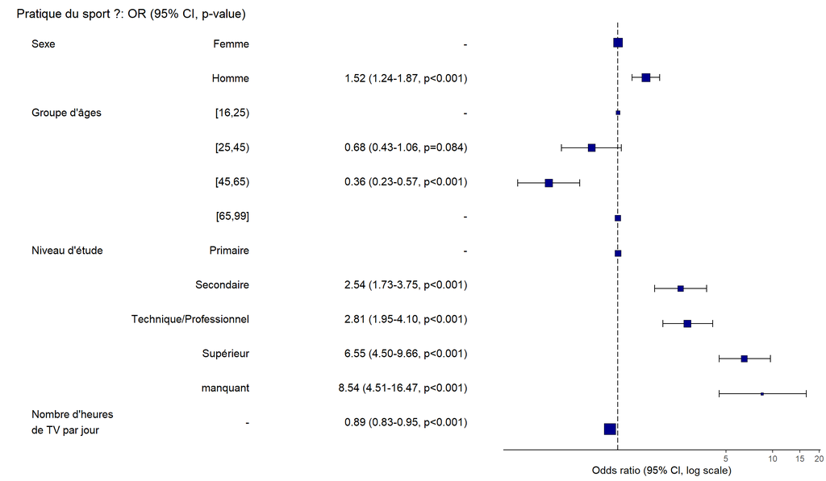

Graphique des odds ratios obtenu avec or_plot

```r
var_label(d$heures.tv) <- "Nombre d'heures\nde TV par jour"
or_plot(d, dep, vars_multi)
```

**ATTENTION :** `or_plot` n’est pas compatible avec les effets d’interactions (cf. ci-dessous).

### Effets d’interaction dans le modèle

Voir le chapitre dédié aux effets d’interaction.

### Multicolinéarité

Voir le chapitre dédié.

## Régression logistique multinomiale

La régression logistique multinomiale est une extension de la régression logistique aux variables qualitatives à trois modalités ou plus. Dans ce cas de figure, chaque modalité de la variable d’intérêt sera comparée à la modalité de réference. Les *odds ratio* seront donc exprimés par rapport à cette dernière.

Nous allons prendre pour exemple la variable *trav.satisf*, à savoir la satisfaction ou l’insatisfaction au travail.

```r
freq(d$trav.satisf)
```

```
##                  n    % val%
## Satisfaction   480 24.0 45.8
## Insatisfaction 117  5.9 11.2
## Equilibre      451 22.6 43.0
## NA             952 47.6   NA
```

Nous allons choisir comme modalité de référence la position intermédiaire, à savoir l’« équilibre ».

```r
d$trav.satisf <- relevel(d$trav.satisf, "Equilibre")
```

Enfin, nous allons aussi en profiter pour raccourcir les étiquettes de la variable *trav.imp* :

```r
levels(d$trav.imp) <- c("Le plus", "Aussi", "Moins", "Peu")
```

Pour calculer un modèle logistique multinomial, nous allons utiliser la fonction `multinom` de l’extension `nnet`[^5]. La syntaxe de `multinom` est similaire à celle de `glm`, le paramètre `family` en moins.

```r
library(nnet)
regm <- multinom(trav.satisf ~ sexe + etud + grpage + trav.imp, data = d)
```

Comme pour la régression logistique, il est possible de réaliser une sélection pas à pas descendante :

```r
regm2 <- step(regm)
```

```
## Start:  AIC=1987.04
## trav.satisf ~ sexe + etud + grpage + trav.imp
##
## trying - sexe
## trying - etud
## trying - grpage
## trying - trav.imp
##            Df      AIC
## - grpage   18 1982.345
## - sexe     22 1984.588
## <none>     24 1987.044
## - etud     16 1995.526
## - trav.imp 18 2024.758
##
## Step:  AIC=1982.34
## trav.satisf ~ sexe + etud + trav.imp
##
## trying - sexe
## trying - etud
## trying - trav.imp
##            Df      AIC
## - sexe     16 1979.857
## <none>     18 1982.345
## - etud     10 1990.172
## - trav.imp 12 2020.409
##
## Step:  AIC=1979.86
## trav.satisf ~ etud + trav.imp
##
## trying - etud
## trying - trav.imp
##            Df      AIC
## <none>     16 1979.857
## - etud      8 1988.068
## - trav.imp 10 2016.791
```

La plupart des fonctions vues précédemment fonctionnent :

```r
summary(regm2)
```

```
## Call:
## multinom(formula = trav.satisf ~ etud + trav.imp, data = d)
##
## Coefficients:
##                (Intercept) etudSecondaire etudTechnique/Professionnel
## Satisfaction    -0.1110996     0.04916210                  0.07793241
## Insatisfaction  -1.1213760    -0.09737523                  0.08392603
##                etudSupérieur etudmanquant trav.impAussi trav.impMoins
## Satisfaction      0.69950061  -0.53841577     0.2578973    -0.1756206
## Insatisfaction    0.07755307  -0.04364055    -0.2279774    -0.5330349
##                trav.impPeu
## Satisfaction    -0.5995051
## Insatisfaction   1.3401509
##
## Std. Errors:
##                (Intercept) etudSecondaire etudTechnique/Professionnel
## Satisfaction     0.4520902      0.2635573                   0.2408483
## Insatisfaction   0.6516992      0.3999875                   0.3579684
##                etudSupérieur etudmanquant trav.impAussi trav.impMoins
## Satisfaction       0.2472571    0.5910993     0.4260623     0.4115818
## Insatisfaction     0.3831110    0.8407592     0.6213781     0.5941721
##                trav.impPeu
## Satisfaction     0.5580115
## Insatisfaction   0.6587383
##
## Residual Deviance: 1947.857
## AIC: 1979.857
```

```r
odds.ratio(regm2)
```

```
##                                                  OR    2.5 %  97.5 %        p
## Satisfaction/(Intercept)                   0.894850 0.368918  2.1706 0.805878
## Satisfaction/etudSecondaire                1.050391 0.626629  1.7607 0.852027
## Satisfaction/etudTechnique/Professionnel   1.081050 0.674272  1.7332 0.746260
## Satisfaction/etudSupérieur                 2.012747 1.239720  3.2678 0.004669
## Satisfaction/etudmanquant                  0.583672 0.183242  1.8591 0.362363
## Satisfaction/trav.impAussi                 1.294206 0.561485  2.9831 0.544977
## Satisfaction/trav.impMoins                 0.838936 0.374447  1.8796 0.669600
## Satisfaction/trav.impPeu                   0.549083 0.183932  1.6391 0.282661
## Insatisfaction/(Intercept)                 0.325831 0.090838  1.1687 0.085306
## Insatisfaction/etudSecondaire              0.907216 0.414229  1.9869 0.807660
## Insatisfaction/etudTechnique/Professionnel 1.087548 0.539194  2.1936 0.814635
## Insatisfaction/etudSupérieur               1.080640 0.510007  2.2897 0.839581
## Insatisfaction/etudmanquant                0.957298 0.184243  4.9740 0.958603
## Insatisfaction/trav.impAussi               0.796142 0.235544  2.6910 0.713701
## Insatisfaction/trav.impMoins               0.586821 0.183124  1.8805 0.369663
## Insatisfaction/trav.impPeu                 3.819620 1.050270 13.8912 0.041909
##
## Satisfaction/(Intercept)
## Satisfaction/etudSecondaire
## Satisfaction/etudTechnique/Professionnel
## Satisfaction/etudSupérieur                 **
## Satisfaction/etudmanquant
## Satisfaction/trav.impAussi
## Satisfaction/trav.impMoins
## Satisfaction/trav.impPeu
## Insatisfaction/(Intercept)                 .
## Insatisfaction/etudSecondaire
## Insatisfaction/etudTechnique/Professionnel
## Insatisfaction/etudSupérieur
## Insatisfaction/etudmanquant
## Insatisfaction/trav.impAussi
## Insatisfaction/trav.impMoins
## Insatisfaction/trav.impPeu                 *
## ---
## Signif. codes:  0 '***' 0.001 '**' 0.01 '*' 0.05 '.' 0.1 ' ' 1
```

De même, il est possible de calculer la matrice de confusion :

```r
table(predict(regm2, newdata = d), d$trav.satisf)
```

```
##
##                  Equilibre Satisfaction Insatisfaction
##   Equilibre            262          211             49
##   Satisfaction         171          258             45
##   Insatisfaction        18           11             23
```

La fonction `tidy` peut s’appliquer au résultat de `multinom` :

```r
library(broom)
tidy(regm2, exponentiate = TRUE, conf.int = TRUE)
```

```
## # A tibble: 16 × 8
##    y.level        term   estimate std.error statistic p.value conf.low conf.high
##    <chr>          <chr>     <dbl>     <dbl>     <dbl>   <dbl>    <dbl>     <dbl>
##  1 Satisfaction   (Inte…    0.895     0.452   -0.246  0.806     0.369       2.17
##  2 Satisfaction   etudS…    1.05      0.264    0.187  0.852     0.627       1.76
##  3 Satisfaction   etudT…    1.08      0.241    0.324  0.746     0.674       1.73
##  4 Satisfaction   etudS…    2.01      0.247    2.83   0.00467   1.24        3.27
##  5 Satisfaction   etudm…    0.584     0.591   -0.911  0.362     0.183       1.86
##  6 Satisfaction   trav.…    1.29      0.426    0.605  0.545     0.561       2.98
##  7 Satisfaction   trav.…    0.839     0.412   -0.427  0.670     0.374       1.88
##  8 Satisfaction   trav.…    0.549     0.558   -1.07   0.283     0.184       1.64
##  9 Insatisfaction (Inte…    0.326     0.652   -1.72   0.0853    0.0908      1.17
## 10 Insatisfaction etudS…    0.907     0.400   -0.243  0.808     0.414       1.99
## 11 Insatisfaction etudT…    1.09      0.358    0.234  0.815     0.539       2.19
## 12 Insatisfaction etudS…    1.08      0.383    0.202  0.840     0.510       2.29
## 13 Insatisfaction etudm…    0.957     0.841   -0.0519 0.959     0.184       4.97
## 14 Insatisfaction trav.…    0.796     0.621   -0.367  0.714     0.236       2.69
## 15 Insatisfaction trav.…    0.587     0.594   -0.897  0.370     0.183       1.88
## 16 Insatisfaction trav.…    3.82      0.659    2.03   0.0419    1.05       13.9
```

On notera la présence d’une colonne supplémentaire, y.level. De fait, la fonction `ggcoef` ne peut s’appliquer directement, car les coefficients vont se supperposer.

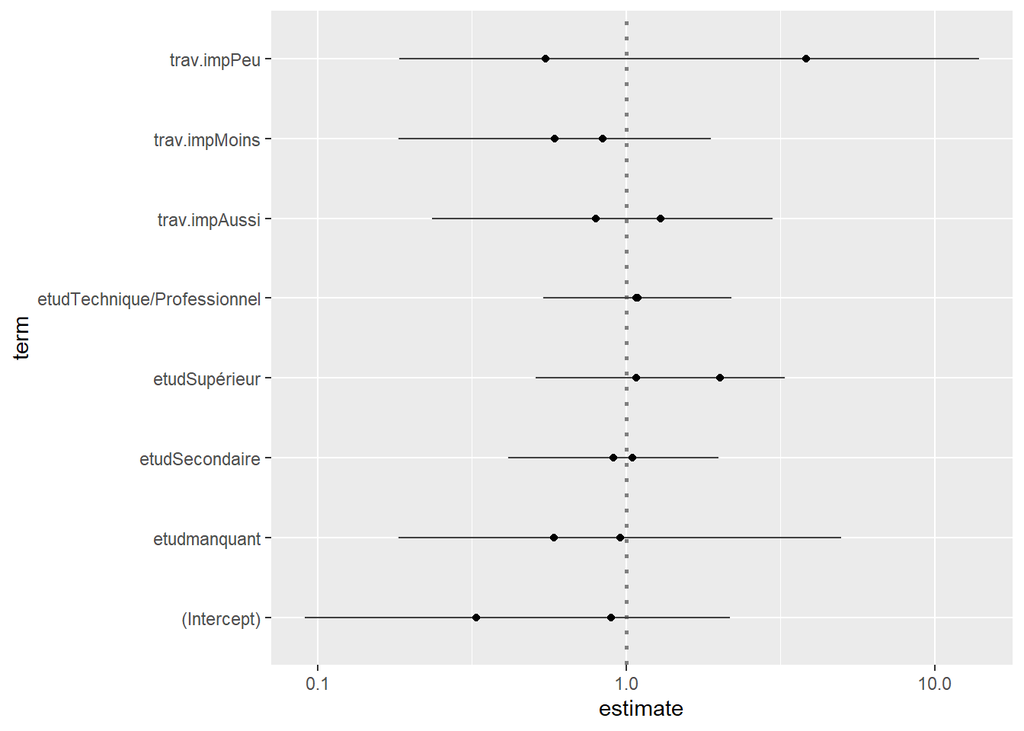

À ne pas faire : appliquer directment ggcoef

```r
ggcoef(regm2, exponentiate = TRUE)
```

On a deux solutions possibles. Pour la première, la plus simple, il suffit d’ajouter des facettes avec `facet_grid`.

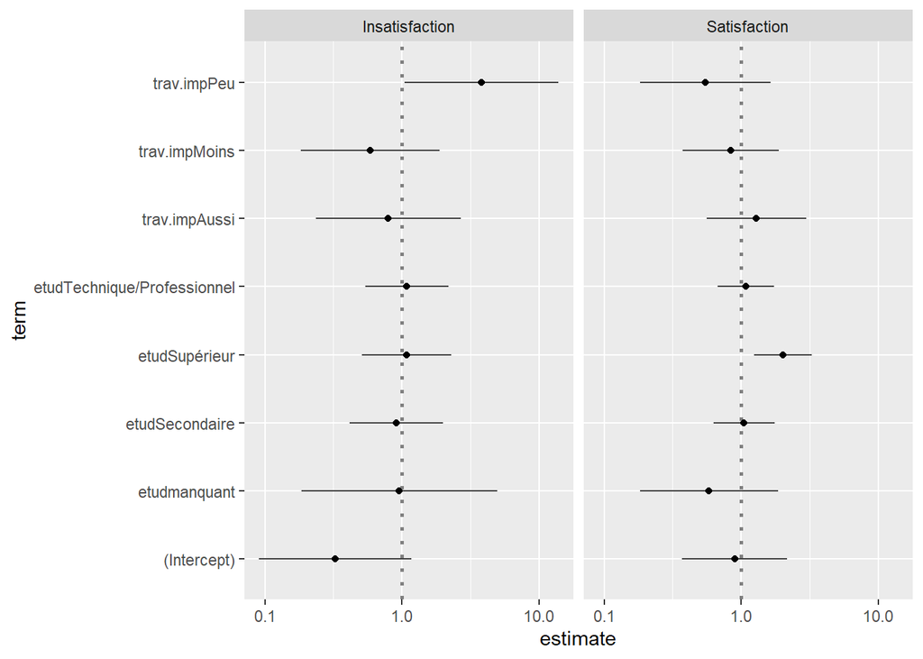

ggcoef avec facet_grid

```r
ggcoef(regm2, exponentiate = TRUE) + facet_grid(~y.level)
```

Pour la seconde, on va réaliser un graphique personnalisé, sur la même logique que `ggcoef`, décalant les points grâce à `position_dodge`.

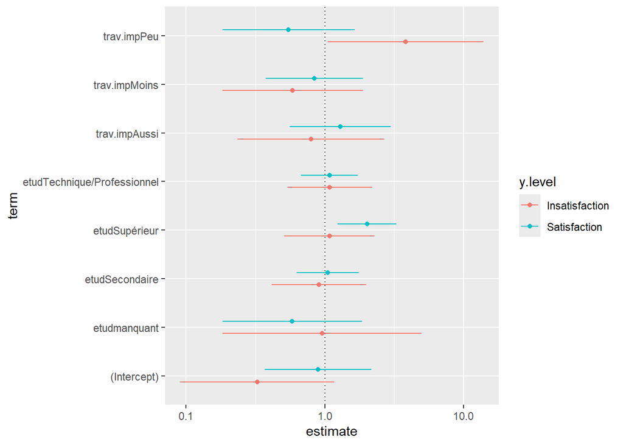

Odds ratio d’un modèle multinomial

```r
ggplot(tidy(regm2, exponentiate = T, conf.int = TRUE)) +
  aes(x = term, y = estimate, ymin = conf.low, ymax = conf.high, color = y.level) +
  geom_hline(yintercept = 1, color = "gray25", linetype = "dotted") +
  geom_errorbar(position = position_dodge(0.5), width = 0) +
  geom_point(position = position_dodge(width = 0.5)) +
  scale_y_log10() +
  coord_flip()
```

## Régression logistique ordinale

La régression logistique ordinale s’applique lorsque la variable à expliquer possède trois ou plus modalités qui sont ordonnées (par exemple : modéré, moyen, fort).

L’extension la plus utilisée pour réaliser des modèles ordinaux est `ordinal` et sa fonction `clm`. Il est même possible de réaliser des modèles ordinaux avec des effets aléatoires (modèles mixtes) à l’aide de la fonction `clmm`.

Pour une bonne introduction à l’extension `ordinal`, on pourra se référer au tutoriel officiel (en anglais) : https://cran.r-project.org/web/packages/ordinal/vignettes/clm_tutorial.pdf.

Une autre introduction pertinente (en français) et utilisant cette fois-ci l’extention `VGAM` et sa fonction `vglm` est disponible sur le site de l’université de Lyon : https://eric.univ-lyon2.fr/~ricco/cours/didacticiels/data-mining/didacticiel_Reg_Logistique_Polytomique_Ordinale.pdf.

On va reprendre l’exemple précédent puisque la variable trav.satisf est une variable ordonnée.

```r
freq(d$trav.satisf)
```

```
##                  n    % val%
## Equilibre      451 22.6 43.0
## Satisfaction   480 24.0 45.8
## Insatisfaction 117  5.9 11.2
## NA             952 47.6   NA
```

**ATTENTION :** Dans le cas d’une régression logistique ordinale, il importante que les niveaux du facteur soient classés selon leur ordre hiéarchique (du plus faible au plus fort). On va dès lors recoder notre variable à expliquer.

```r
d$trav.satisf <- factor(d$trav.satisf, c("Insatisfaction", "Equilibre", "Satisfaction"), ordered = TRUE)
freq(d$trav.satisf)
```

```
##                  n    % val%
## Insatisfaction 117  5.9 11.2
## Equilibre      451 22.6 43.0
## Satisfaction   480 24.0 45.8
## NA             952 47.6   NA
```

```r
library(ordinal)
rego <- clm(trav.satisf ~ sexe + etud + trav.imp, data = d)
summary(rego)
```

```
## formula: trav.satisf ~ sexe + etud + trav.imp
## data:    d
##
##  link  threshold nobs logLik  AIC     niter max.grad cond.H
##  logit flexible  1048 -978.61 1977.23 5(0)  5.41e-09 3.9e+02
##
## Coefficients:
##                             Estimate Std. Error z value Pr(>|z|)
## sexeHomme                   -0.16141    0.12215  -1.321 0.186369
## etudSecondaire               0.05558    0.23220   0.239 0.810819
## etudTechnique/Professionnel  0.03373    0.21210   0.159 0.873660
## etudSupérieur                0.61336    0.21972   2.792 0.005245 **
## etudmanquant                -0.45555    0.48761  -0.934 0.350174
## trav.impAussi                0.35104    0.38578   0.910 0.362857
## trav.impMoins                0.02616    0.37174   0.070 0.943896
## trav.impPeu                 -1.66062    0.46204  -3.594 0.000325 ***
## ---
## Signif. codes:  0 '***' 0.001 '**' 0.01 '*' 0.05 '.' 0.1 ' ' 1
##
## Threshold coefficients:
##                          Estimate Std. Error z value
## Insatisfaction|Equilibre  -2.0226     0.4189  -4.829
## Equilibre|Satisfaction     0.3391     0.4113   0.825
## (952 observations deleted due to missingness)
```

Une fois encore, il est possible de faire une sélection descendane pas à pas.

```r
rego2 <- step(rego)
```

```
## Start:  AIC=1977.23
## trav.satisf ~ sexe + etud + trav.imp
##
##            Df    AIC
## - sexe      1 1977.0
## <none>        1977.2
## - etud      4 1990.6
## - trav.imp  3 2013.2
##
## Step:  AIC=1976.97
## trav.satisf ~ etud + trav.imp
##
##            Df    AIC
## <none>        1977.0
## - etud      4 1990.6
## - trav.imp  3 2011.6
```

[^1]: Il existe également une fonction `add.NA` fournie avec **R**. Mais elle ne permet pas de choisir l’étiquette du nouveau niveau créé. Plus spécfiquement, cette étiquette est `NA` et non une valeur textuelle, ce qui peut créer des problèmes avec certaines fonctions.
[^2]: Pour plus de détails, voir http://www.spc.univ-lyon1.fr/polycop/odds%20ratio.htm.
[^3]: Il existe également des méthodes de *sélection ascendante pas à pas*, mais nous les aborderons pas ici.
[^4]: On ne peut donc exclure la présence éventuelle de bugs non encore corrigés.
[^5]: Une alternative est d’avoir recours à l’extension `mlogit` que nous n’aborderons pas ici. Voir http://www.ats.ucla.edu/stat/r/dae/mlogit.htm (en anglais) pour plus de détails.